# Perspectives on Computational Modeling

Problem Set #6

Xingyun Wu

2/18/2017

## Part 1: Modeling voter turnout

### Describe the data

[output not shown]

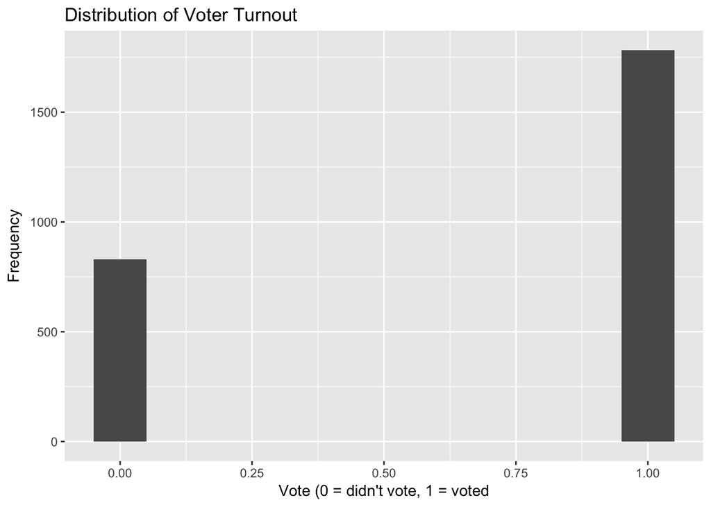

2. The required scatter plot is shown as below. It shows that there is a negative linear relationship between mental health and observed voter turnout. If individual is more depressed, he/she is more likely to have no political participation. The problematic part is that the linear smoothing line assumes the voter turnout to be an continuous variable with range (0.25, 0.75). In fact, the voter turnout is a binary variable with value as either 0 or 1. The prediction made by the smoothing line does not match the binomial distribution of voter turnout.

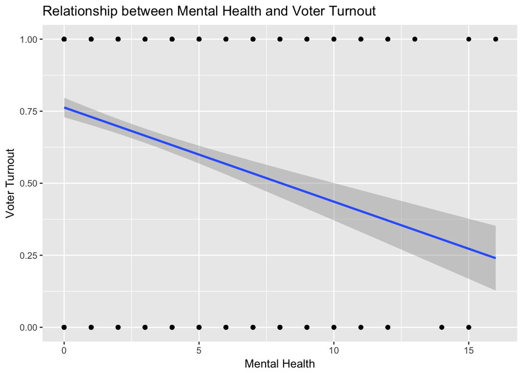

### Basic model

Here is the logistic regression model of the relationship between mental health and voter turnout:

```
##
## Call:
## glm(formula = vote96 ~ mhealth_sum, family = binomial(link = "logit"),
##     data = mhlth)
##
## Deviance Residuals:
##     Min       1Q   Median       3Q      Max
## -1.6834  -1.2977   0.7452   0.8428   1.6911
##
## Coefficients:
##             Estimate Std. Error z value Pr(>|z|)
## (Intercept)  1.13921    0.08444  13.491  < 2e-16 ***
## mhealth_sum -0.14348    0.01969  -7.289 3.13e-13 ***
## ---
## Signif. codes:  0 '***' 0.001 '**' 0.01 '*' 0.05 '.' 0.1 ' ' 1
##
## (Dispersion parameter for binomial family taken to be 1)
##
##     Null deviance: 1672.1  on 1321  degrees of freedom
## Residual deviance: 1616.7  on 1320  degrees of freedom
##   (1510 observations deleted due to missingness)
## AIC: 1620.7
##
## Number of Fisher Scoring iterations: 4
```

1. The relationship is negatve and is both statistically and substantively significant. The parameters for both the constant tne the `mental health` is statistially significant, with significant level 0.001. Although the magnitude of the parameter of `mental health` does not seem to be big, it is still different from 0 .
2. The graph below shows the relationship between mental health and the log-odds of voter turnout. It shows a linear relationship: the a one-unit increase in `mental health` is associated with an decrease in log odds of `voter96` by 0.1434752 unit.

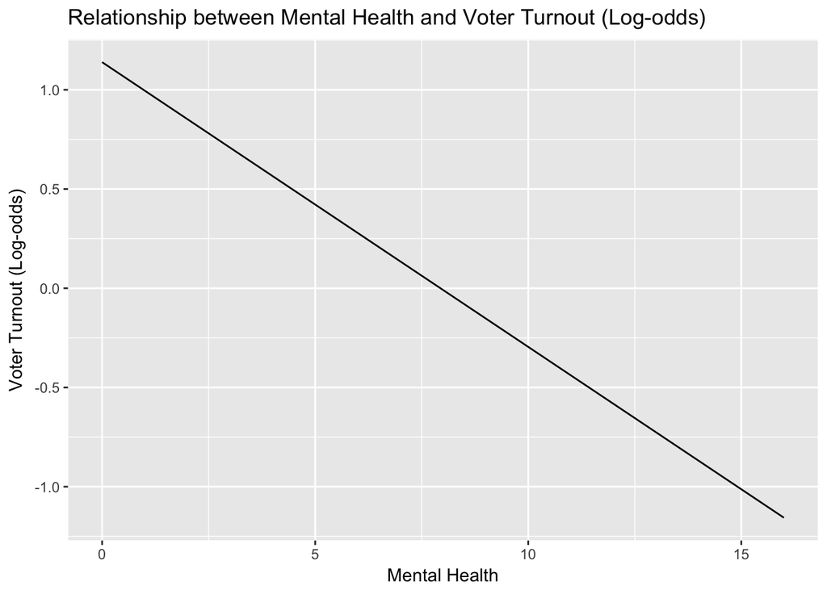

3. The graph below shows the relationship between mental health and the odds of voter turnout. It shows a one-unit increase in `mental health` would lead to a decrease in the odds of voting, which is the probability to vote over the probability to not vote. But the relationship is not linear.

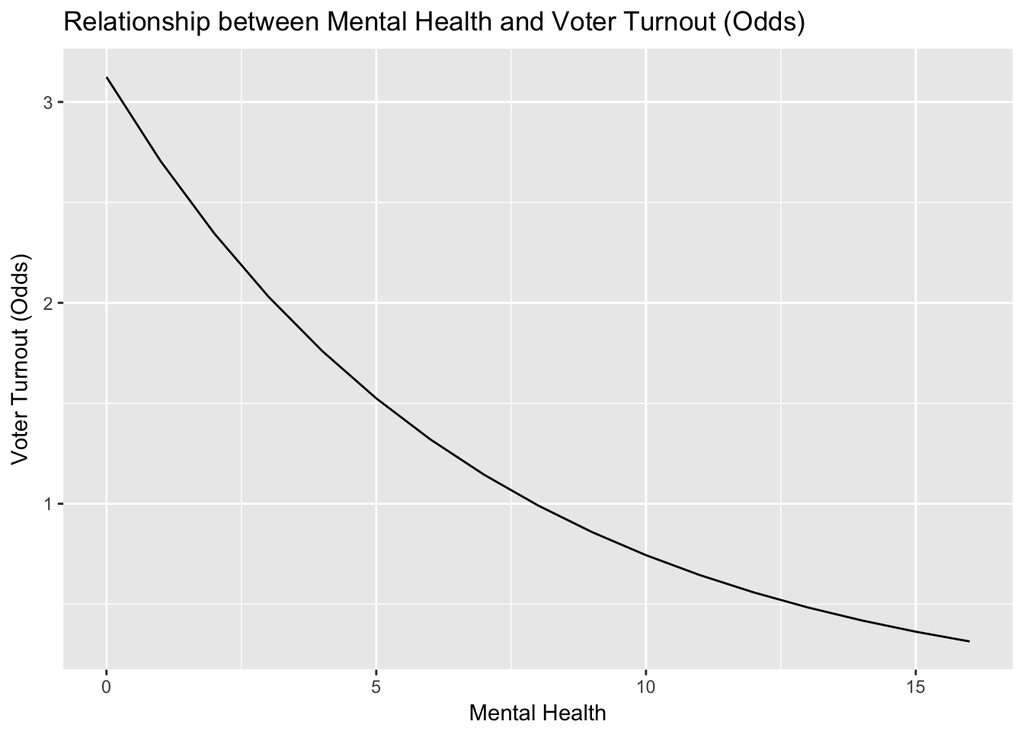

4. The graph below shows the relationship between mental health and the probability of voter turnout. It shows one unit of increase in mental health would decrease individuals’ probability to vote. But the relationship is not strictly linear. The first diffference for an increase in the `mental health` index from 1 to 2 is: -0.02917824. The first difference for an increase in the `mental health` from 5 to 6 is: -0.03477821. This shows the relationship between `mental health` and `voter turnout` is not linear in terms of probabilities.

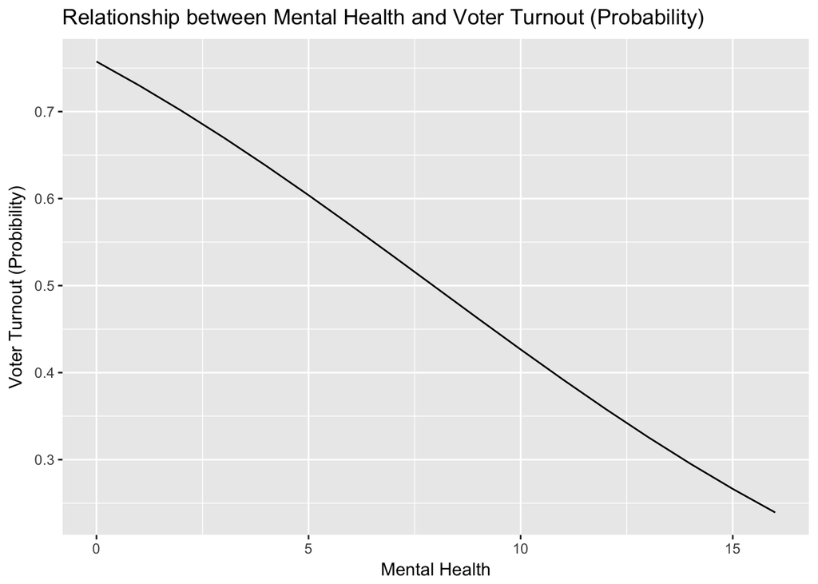

5. The accuracy rate is 0.677761, which means about 67.78% of the predictions based on `mental health` only were correct. The PRE of the model is 0.01616628, which means the model reduced the error from the null model by about 1.62%. The AUC is 0.6243, indicating that area under the ROC curve is about 62.43%. I think the model is not very accurate, given by its accuracy rate. And it is difficult to say it to be good, since the PRE just slightly increased.

```
## [1] 0.677761
```

```
## [1] 0.01616628
```

```
## Area under the curve: 0.6243
```

### Multiple variable model

1. My model of interest is the relationship between voter turnout and `mental health`, `age`, and `education`. First, `mental health` is used because it is statistically significant in the basic model. Depression may reduce political participation by increasing individuals’ feelings of hopelessness. Second, oder people may be more likely to participate in elections, because they tend to have more time and income. So I take `age` into consideration. Third, individuals with more years of `education` may be more interested in political participation. So it is also included in my model of interest.
   1. The probability distribution is Bernoulli distribution.
   2. The linear predictor is:
      $$vote96_{i}=\beta_{0}+\beta{1}*mhealth\_sum+\beta_{2}*age+\beta_{3}*educ+\beta_{4}*black+\beta_{5}*female+\beta_{6}*married+\beta_{7}*inc10$$
      .
   3. The link function is:
      $$Y{i}=e^{vote96_{i}}/(1+e^{vote96_{i}})$$
      .
2. The result of estimated model is:

```
##
## Call:
## glm(formula = vote96 ~ mhealth_sum + age + educ + black + female +
##     married + inc10, family = binomial, data = mhlth)
##
## Deviance Residuals:
##     Min       1Q   Median       3Q      Max
## -2.4843  -1.0258   0.5182   0.8428   2.0758
##
## Coefficients:
##              Estimate Std. Error z value Pr(>|z|)
## (Intercept) -4.304103   0.508103  -8.471  < 2e-16 ***
## mhealth_sum -0.089102   0.023642  -3.769 0.000164 ***
## age          0.042534   0.004814   8.835  < 2e-16 ***
## educ         0.228686   0.029532   7.744 9.65e-15 ***
## black        0.272984   0.202585   1.347 0.177820
## female      -0.016969   0.139972  -0.121 0.903507
## married      0.296915   0.153164   1.939 0.052557 .
## inc10        0.069614   0.026532   2.624 0.008697 **
## ---
## Signif. codes:  0 '***' 0.001 '**' 0.01 '*' 0.05 '.' 0.1 ' ' 1
##
## (Dispersion parameter for binomial family taken to be 1)
##
##     Null deviance: 1468.3  on 1164  degrees of freedom
## Residual deviance: 1241.8  on 1157  degrees of freedom
##   (1667 observations deleted due to missingness)
## AIC: 1257.8
##
## Number of Fisher Scoring iterations: 4
```

```
## [1] 0.1481481
```

[output not shown]

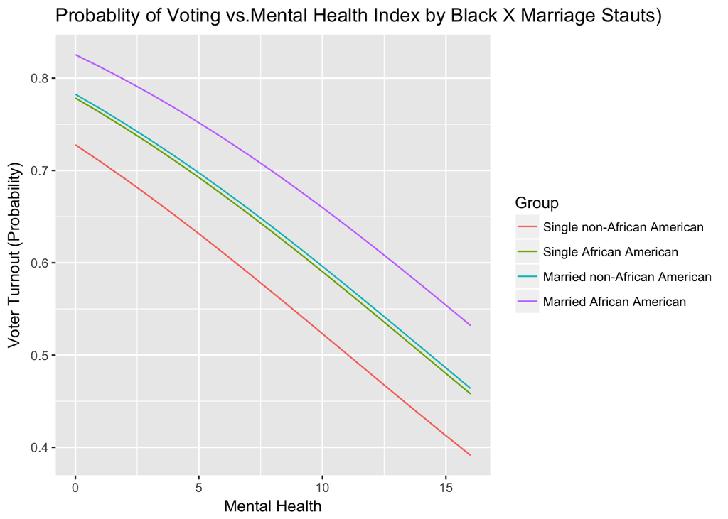

## Part 2: Modeling tv consumption

```
##
## Call:
## glm(formula = tvhours ~ age + educ + black, family = "poisson",
##     data = gss)
##
## Deviance Residuals:
##     Min       1Q   Median       3Q      Max
## -2.9704  -0.8863  -0.2543   0.4560   6.8740
##
## Coefficients:
##               Estimate Std. Error z value Pr(>|z|)
## (Intercept)  1.2788355  0.0795195  16.082  < 2e-16 ***
## age          0.0062213  0.0008109   7.672 1.69e-14 ***
## educ        -0.0444710  0.0045456  -9.783  < 2e-16 ***
## black        0.4581913  0.0334897  13.682  < 2e-16 ***
## ---
## Signif. codes:  0 '***' 0.001 '**' 0.01 '*' 0.05 '.' 0.1 ' ' 1
##
## (Dispersion parameter for poisson family taken to be 1)
##
##     Null deviance: 2657.4  on 1712  degrees of freedom
## Residual deviance: 2296.2  on 1709  degrees of freedom
##   (2797 observations deleted due to missingness)
## AIC: 6947.8
##
## Number of Fisher Scoring iterations: 5
```